# DASI Course Project

October 2014

### Introduction:

Since 1972, the General Social Survey (GSS) has been monitoring societal change and studying the growing complexity of American society. The GSS aims to gather data on contemporary American society in order to monitor and explain trends and constants in attitudes, behaviors, and attributes; to examine the structure and functioning of society in general as well as the role played by relevant subgroups; to compare the United States to other societies in order to place American society in comparative perspective and develop cross-national models of human society; and to make high-quality data easily accessible to scholars, students, policy makers, and others, with minimal cost and waiting.

GSS questions cover a diverse range of issues including national spending priorities, marijuana use, crime and punishment, race relations, quality of life, confidence in institutions, and sexual behavior. This extract of the General Social Survey (GSS) Cumulative File 1972-2012 provides a sample of selected indicators in the GSS. Unlike the full General Social Survey Cumulative File, missing values have been removed from the responses and factor variables were created when appropriate to facilitate analysis using R. Other than the two modifications mentioned above, all data and coding come from the original dataset.

Research Question: Is there an association between views about a married person having sexual relations with someone other than the marriage partner and education level (highest year of school completed)?

### Data:

Data for this analysis was collected by:

Smith, Tom W., Michael Hout, and Peter V. Marsden. General Social Survey, 1972-2012 [Cumulative File]. ICPSR34802-v1. Storrs, CT: Roper Center for Public Opinion Research, University of Connecticut /Ann Arbor, MI: Inter-university Consortium for Political and Social Research [distributors], 2013-09-11. Persistent URL: http://doi.org/10.3886/ICPSR34802.v1

The data consists of 57,061 observations with 115 variables. Each observation represents an individual who participated in the survey. The two variables of interest in this observational analysis are:

educ (highest year of school completed) Numeric. xmarsex (sex with person other than spouse) Categorical. This variable is coded as a factor with 4 levels (“Always Wrong” “Almost Always Wrong” Sometimes Wrong" “Not Wrong at All” ).

N/A responses were removed from the data before analysis. The final number of observations in this study was 33.939. Because this study is observational, causation cannot be established. The population of interest is all non institutionalized, English and Spanish speaking persons 18 years of age or older, living in the United States. Based on the sampling procedures described by Smith, Tom W., Michael Hout, and Peter V. Marsden, the results are generalizable to the population of interest.

```r
# Load the required libraries
require("nortest")
require("lawstat")
```

```r
##Set working directory to data directory
setwd('C:/Users/bryan_000/Documents/GitHub/Data/')
#Check for the data directory and data file. If the data file is not there, download it.
if(!file.exists("data")){
  dir.create("data")
  data.url <- 'http://d396qusza40orc.cloudfront.net/statistics/project/gss.csv'
  download.file(data.url, destfile = 'data/gss.csv')
}

# read the data file
gss <- read.table("data/gss.csv", header = TRUE, sep =",")
#names(gss)
#remove all other variables except the 2 we will work with
gss <- subset(gss, select=c("educ","xmarsex"))
#Remove na's from the data
gss <- na.omit(gss)
```

### Exploratory data analysis:

Exploratory data analysis was performed using a histogram of the Years of Education variable, bar plots of the view of extra marital sex variable, box plots combining the two variables, and the 5 number numerical summary.

#### Visual Displays of the Variables

##### Histogram (Vertical red line indicates grand mean)

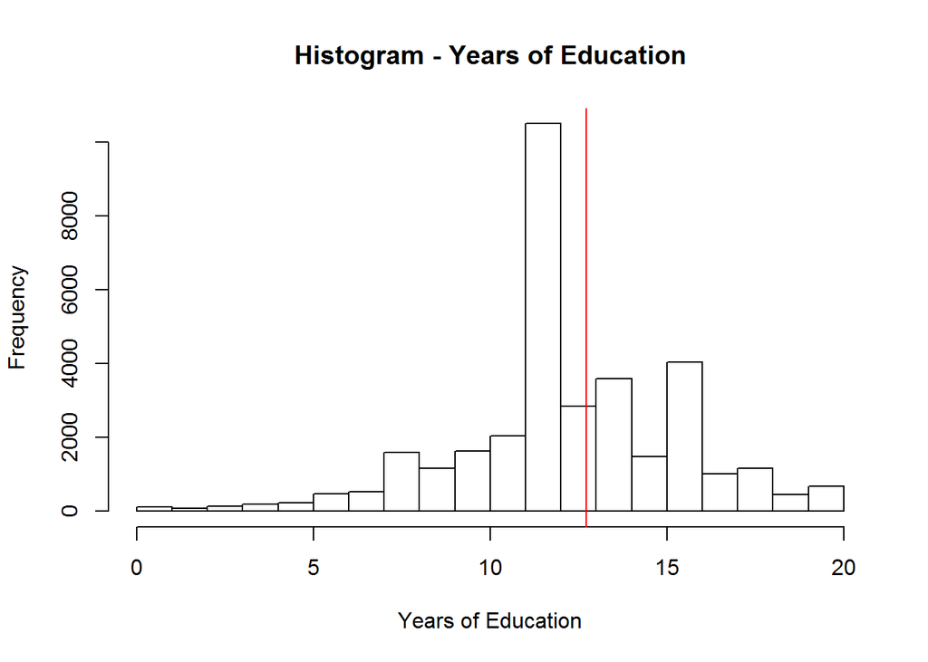

Years of education are not normally distributed. The histogram indicates a left skewed distribution.

##### Barplot

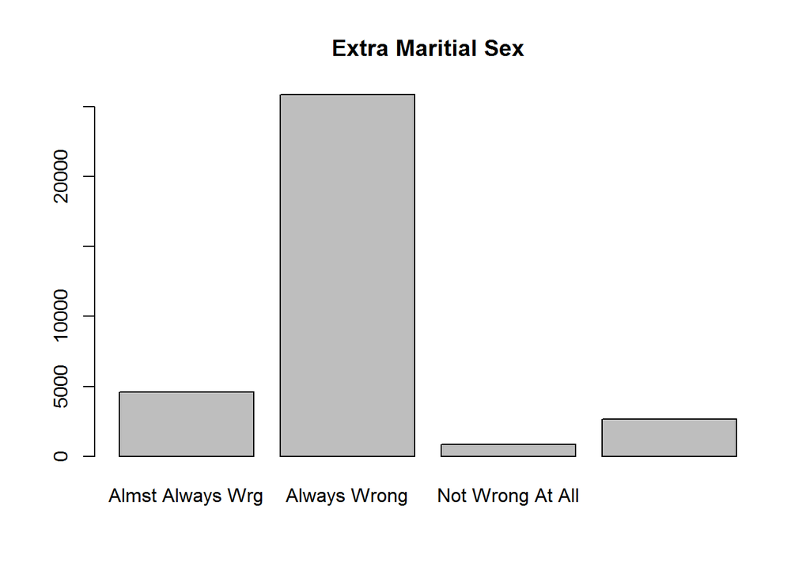

The “Aways Wrong” response is the most common response.

##### Boxplots (Horizontal red line indicates grand mean)

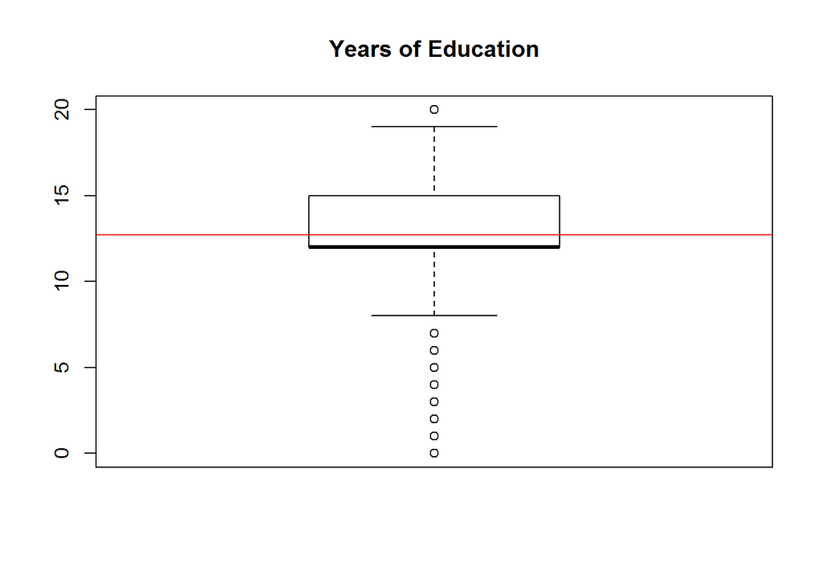

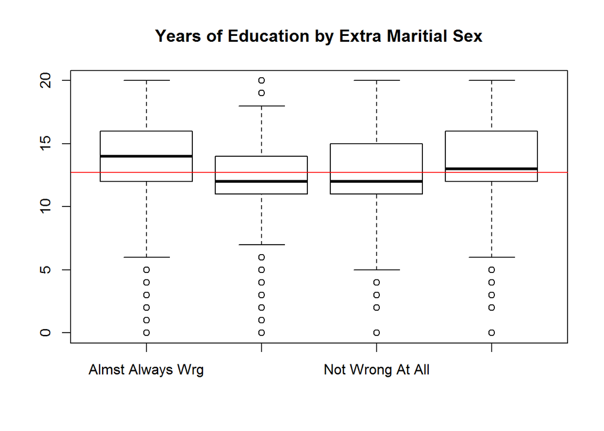

There are differences in the median Years of Education when factored by the Extra Martial Sex variables.

#### Numerical Summaries of the Variables

##### Five number summary of Years of Education by Extra Maritial Sex

```r
by (gss$educ, gss$xmarsex, summary)
```

```
## gss$xmarsex: Almst Always Wrg
##    Min. 1st Qu.  Median    Mean 3rd Qu.    Max.
##    0.00   12.00   14.00   13.81   16.00   20.00
## --------------------------------------------------------
## gss$xmarsex: Always Wrong
##    Min. 1st Qu.  Median    Mean 3rd Qu.    Max.
##    0.00   11.00   12.00   12.45   14.00   20.00
## --------------------------------------------------------
## gss$xmarsex: Not Wrong At All
##    Min. 1st Qu.  Median    Mean 3rd Qu.    Max.
##       0      11      12      13      15      20
## --------------------------------------------------------
## gss$xmarsex: Sometimes Wrong
##    Min. 1st Qu.  Median    Mean 3rd Qu.    Max.
##    0.00   12.00   13.00   13.28   16.00   20.00
```

Exploratory analysis of theses variables appear to indicate that a relationship between these variables does exist.

### Inference:

One-way analysis of variance (ANOVA) was chosen to analyze the variables in this study. ANOVA is a technique used to compare means of two or more samples using the F distribution. The ANOVA will be used to test the null hypothesis that responses to the material sex variable are drawn from populations with the same mean value of the years of education variable. The alternative hypothesis is that at least on category has a mean that is different.

#### One-Way ANOVA

The ANOVA produces an F-statistic, the ratio of the variance calculated among the means to the variance within the samples. If the group means are drawn from populations with the same mean values, the variance between the group means should be lower than the variance of the samples. A higher ratio implies that the samples were drawn from populations with different mean values.

ANOVA makes the following assumptions:

Random sampling, or at the very least, random assignment to groups. Independence of scores on the response variable – i.e., what you get from one subject should be in no way influenced by what you get from any of the others. Sampling from normal populations within each cell of the design. Homogeneity of variance – the populations within each cell of the design should all have the same variance.

The last two are assumptions will be checked statistically before the ANOVA.

#### Testing For Homogeneity of Variance

Bartlett’s test is used to test if k samples are from populations with equal variances. Equal variances across samples is called homoscedasticity or homogeneity of variances. Bartlett’s test is used to test the null hypothesis that all k population variances are equal against the alternative that at least two are different.

```r
bartlett.test(educ ~ xmarsex, data=gss)
```

```
##
##  Bartlett test of homogeneity of variances
##
## data:  educ by xmarsex
## Bartlett's K-squared = 3.9586, df = 3, p-value = 0.266
```

The p-value is > .05, so we do not reject the null hypothesis of equal group variances.

#### Testing for Normality

The Anderson-Darling test is a statistical test of whether a given sample of data is drawn from a given probability distribution. When testing for normality, the null hypothesis is that the data are normally distributed; the alternative hypothesis is that the data are non-normal; therefore, if the p-value is less than a chosen alpha, then reject the null hypothesis that the data come from that distribution.

```r
by(gss$educ, gss$xmarsex, ad.test)
```

```
## gss$xmarsex: Almst Always Wrg
##
##  Anderson-Darling normality test
##
## data:  dd[x, ]
## A = 67.5936, p-value < 2.2e-16
##
## --------------------------------------------------------
## gss$xmarsex: Always Wrong
##
##  Anderson-Darling normality test
##
## data:  dd[x, ]
## A = 509.2825, p-value = Inf
##
## --------------------------------------------------------
## gss$xmarsex: Not Wrong At All
##
##  Anderson-Darling normality test
##
## data:  dd[x, ]
## A = 9.6965, p-value < 2.2e-16
##
## --------------------------------------------------------
## gss$xmarsex: Sometimes Wrong
##
##  Anderson-Darling normality test
##
## data:  dd[x, ]
## A = 39.5463, p-value < 2.2e-16
```

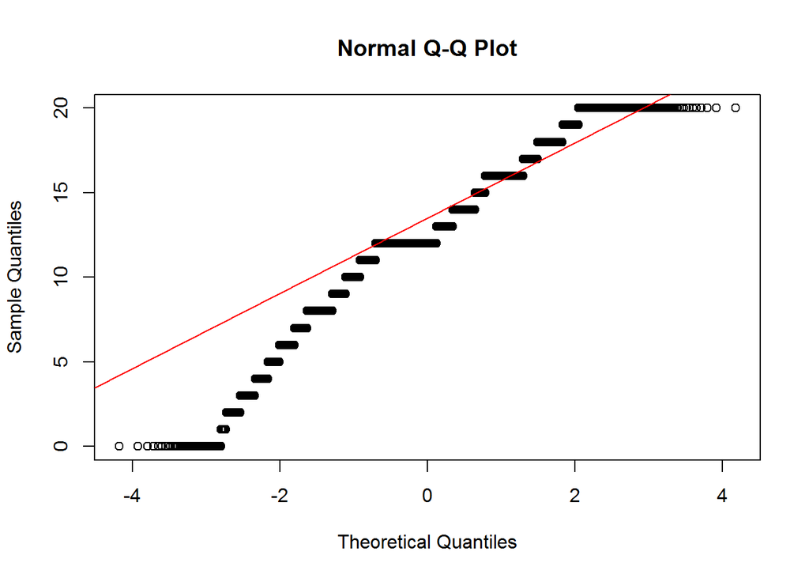

```r
qqnorm(gss$educ)
qqline(gss$educ, col="red")
```

Because the p-value < .05, we reject the null hypothesis of normality. If there are a great many data points, which is the case in this study, the normality test may detect statistically significant but trivial departures from normality that will have no real effect on the F statistic. The one-way ANOVA is considered a robust test against the normality assumption. This means that it tolerates violations to its normality assumption rather well. With fairly small, moderate, and large sample sizes, the test may yield reasonably accurate p values even when the normality assumption is violated. Large sample sizes may be required to produce relatively valid p values if the population distributions are substantially not normal. As regards the normality of group data, the one-way ANOVA can tolerate data that is non-normal (skewed or kurtotic distributions) with only a small effect on the Type I error rate.

#### One-Way ANOVA

```r
output <- aov(gss$educ~gss$xmarsex)
model.tables(output,"means")
```

```
## Tables of means
## Grand mean
##
## 12.71024
##
##  gss$xmarsex
##     Almst Always Wrg Always Wrong Not Wrong At All Sometimes Wrong
##                13.81        12.45               13           13.28
## rep          4571.00     25864.00              855         2649.00
```

```r
summary(output)
```

```
##                Df Sum Sq Mean Sq F value Pr(>F)
## gss$xmarsex     3   8261  2753.8   278.3 <2e-16 ***
## Residuals   33935 335835     9.9
## ---
## Signif. codes:  0 '***' 0.001 '**' 0.01 '*' 0.05 '.' 0.1 ' ' 1
```

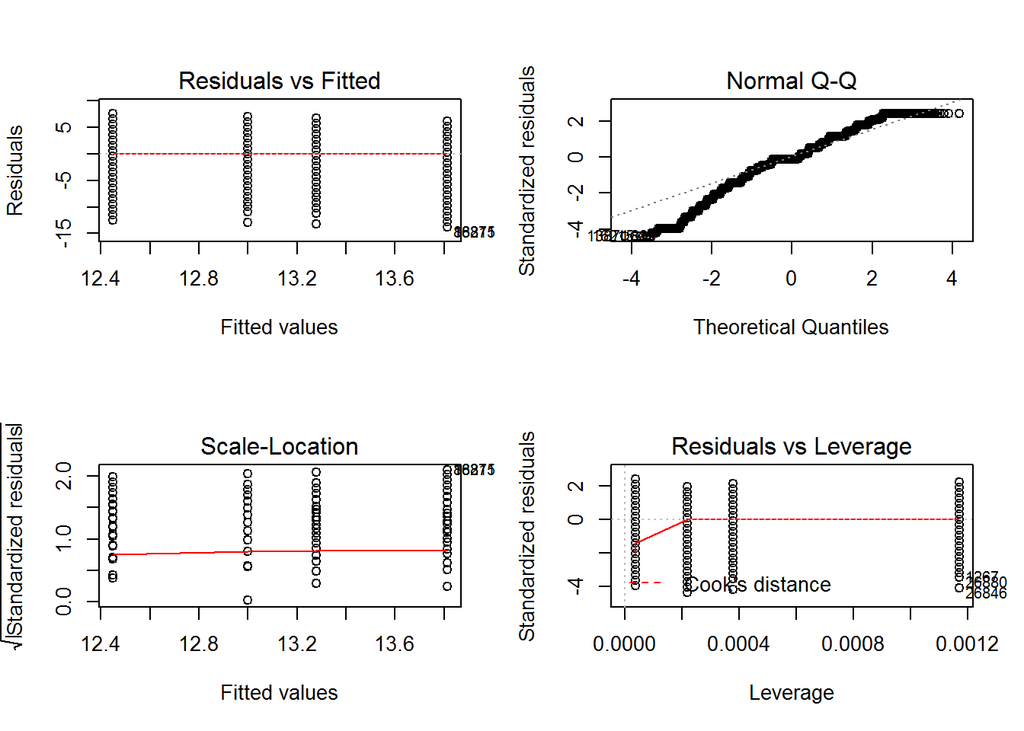

```r
par(mfrow = c(2, 2))
plot(output)
```

The p-value is < .05, so we reject the null hypothesis of equal group means. We found evidence at least one group mean is different from the others. In order to determine which group mean or means is (are) different, we conducted post-hoc analysis using the Tukey Honestly Significant Difference test

#### Post-Hoc Analysis

Post hoc tests are designed for situations in which the researcher has already obtained a significant omnibus F-test with a factor that consists of three or more means and additional exploration of the differences among means is needed to provide specific information on which means are significantly different from each other. The Tukey HSD procedure prints out the difference between means for each pair of groups, the lower and upper limits of a 95% confidence interval for that difference, and the p-value for the Tukey test.

```r
TukeyHSD(output)
```

```
##   Tukey multiple comparisons of means
##     95% family-wise confidence level
##
## Fit: aov(formula = gss$educ ~ gss$xmarsex)
##
## $`gss$xmarsex`
##                                         diff         lwr        upr
## Always Wrong-Almst Always Wrg     -1.3651473 -1.49481802 -1.2354766
## Not Wrong At All-Almst Always Wrg -0.8152904 -1.11642447 -0.5141563
## Sometimes Wrong-Almst Always Wrg  -0.5358655 -0.73321259 -0.3385185
## Not Wrong At All-Always Wrong      0.5498569  0.26893355  0.8307803
## Sometimes Wrong-Always Wrong       0.8292818  0.66441192  0.9941517
## Sometimes Wrong-Not Wrong At All   0.2794249 -0.03845767  0.5973074
##                                       p adj
## Always Wrong-Almst Always Wrg     0.0000000
## Not Wrong At All-Almst Always Wrg 0.0000000
## Sometimes Wrong-Almst Always Wrg  0.0000000
## Not Wrong At All-Always Wrong     0.0000030
## Sometimes Wrong-Always Wrong      0.0000000
## Sometimes Wrong-Not Wrong At All  0.1079738
```

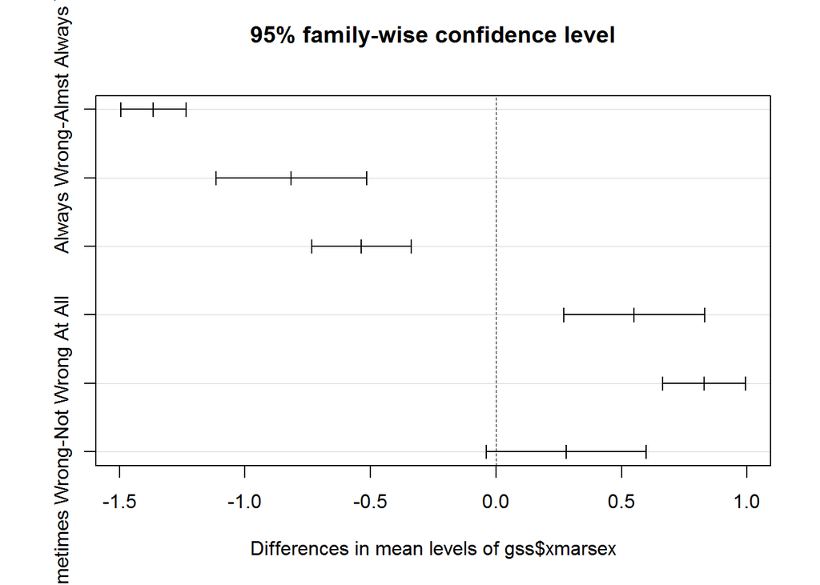

```r
plot(TukeyHSD(output))
```

The p-value for the Tukey HSD test for the pair “Sometimes Wrong” - “Not Wrong At All” was > .05; therefore, we do not reject the null hypothesis of equal group means for this pair. The p-value for the Tukey HSD test for all other pairs was < .05; therefore, we reject the null hypothesis of equal group means for these pairs.

### Conclusion:

The results of the study indicated there is an association between views about a married person having sexual relations with someone other than the marriage partner and education level (highest year of school completed). This was an observational study; therefore, no attempt was made to manipulate variables. As a result, causation cannot be inferred from the results.

## Appendix

One page of data:

```r
head(gss,35)
```

```
##      educ          xmarsex
## 1614    6     Always Wrong
## 1615    8     Always Wrong
## 1616   11  Sometimes Wrong
## 1617   12     Always Wrong
## 1618    8     Always Wrong
## 1619   12     Always Wrong
## 1620    8     Always Wrong
## 1621   16  Sometimes Wrong
## 1622    7     Always Wrong
## 1623   16     Always Wrong
## 1624    8     Always Wrong
## 1625   12     Always Wrong
## 1626    8     Always Wrong
## 1627   12     Always Wrong
```

[output cut: 21 more lines]